# BIOINF3005/7160: Transcriptomics Applications

Data Import Using the Tidyverse

11<sup>th</sup> March, 2020

# Introduction

In our previous sections, we learned how to document our workflow using R Markdown using plain-text paragraphs and R code embedded in the same document. Once we’d learned that, we spent some time learning how to manipulate text strings. For today’s session, we’ll introduce a more common object type, known as a data frame (or tibble) which resembles a spreadsheet. Firstly, we’ll import the file into R, and then we’ll learn how to manipulate the data object inside the R environment.

## Setting up our workspace

Before we go any further, we need to keep developing our good programming practice. If you don’t already have an R Project for `practical_2`, create a new project with this name as a subdirectory of your `transcriptomics_applications` directory. **Call a tutor over if you can’t remember how to do this.**

Once you have an R Project ready to go for `practical_2`, create a new directory called `data` within this directory. Copy the file `Enrichment.csv` to this directory.

Once you have `Enrichment.csv` in your `data` directory, begin a new R Markdown document and save this as `DataImport.Rmd` in your project root directory. As per usual, delete everything after the `setup` chunk.

## Introducting The Tidyverse

Previously we saw the package `stringr` which was dedicated to manipulating text strings. Today we’re going to learn about functions from the packages `readr`, `dplyr`, `tibble` and `tidyr`. Because these packages are very tighly integrated, the authors decided to create a further package called the `tidyverse` which enables the loading of the eight core packages (`ggplot2`, `tibble`, `tidyr`, `readr`, `purrr`, `dplyr`, `stringr` and `forcats`) in one command. An entire programming culture has sprung up around these packages, which is often referred to as the `tidyverse` or `tidy` data, or something similar. In essence, the release of these packages and their ease of use, opened R up to a far wider community. All of these packages are maintained by staff from RStudio, in particular Hadley Wickham, who is one of the most influential figures within the international R community.

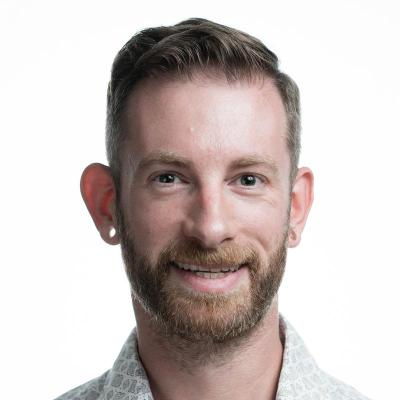

*Hi! I’m Hadley Wickham & I wrote/designed most of the tidyverse. I’m originally from New Zealand, so my functions use English spelling instead of US spelling. Yay!* (source: https://github.com/hadley)

After your `setup` chunk, create a new chunk called `packages` and enter the following code.

```r
library(tidyverse)
```

This will load all 8 of the packages that were described earlier when executed. Compile your document and inspect the output.

You’ll probably notice that this chunk has been rather “chatty” and provided an unexpected amount of output in your final document. The first time you execute this chunk in an interactive session you would have seen the same output appear in your Console (or in your R Markdown if you have it set for that). This is what’s known as a `message` in R, and is just communicating information to us. It may look like like some kind of error, but this one isn’t.

The first few lines are informing us what packages have been loaded, and which versions they are. After `--Conflicts-----` should be two lines letting us know that the function `filter()` from `dplyr` is the first one `R` will look for in the session, and now takes precedence of the function `filter()` from `stats`. Similarly for the function `lag()`. This really isn’t super relevant for us, so we can ignore all of this.

One convenient piece of syntax that is shown here is the use of namespaces. As we can see that two packages have functions called `filter()` that are currently available to use. If we wish to specify which exact one to use, we can put the package name before the function name, and separated by a double colon (`::`). Formally, this is known as a namespace which is essentially a list of functions made visible by loading a package. If we’re wanting to be sure that we’re using `filter()` from `dplyr`, we could write `dplyr::filter()` instead of just using `filter()` and hoping that R figures it out. We won’t come across too many instances of this today, but the more packages we learn about, the more of a useful trick it becomes.

Given that this output is going to make our compiled document look a bit uglier, we can hide this type of output by setting the chunk argument `message = FALSE`. We can do this in the chunk header for this chunk only, or we can add it to our `setup` chunk, inside the call to `knitr::opts_chunk$set()` after `echo = TRUE`. We’ll have to separate these with a comma, but this will then become a global setting so that all messages from any chunks are hidden. This is my preferred option for all of my R Markdown documents. (Notice the use of the namespace trick here to ensure that `opts_chunk$set()` from the package `knitr` is called.)

# Importing Data

Now we’ve started our R Markdown document and tidied up our output, let’s get on with importing data. First, we’ll use the convenient GUI that R Studio provides, but then we’ll ditch this and just use code in the style that we’ve already seen.

## Using the GUI

The file we’ll work with today is called `Enrichment.csv` and contains some actual results from a transcriptomic analysis comparing mutant and wild-type zebrafish. This data was generously provided by Prof Michael Lardelli who does some excellent work in the context of Alzheimer’s Disease. As this is a csv file, we know this will be a plain-text file, with columns separated by the comma symbol.

Using the **Files** pane, navigate into the `data` folder and click on the file `Enrichment.csv`. When prompted, select `View File` and the file will open in your script window, aloowing us to have a sneak peak at it. Note, that **we haven’t loaded it into your R Environment**. We’re just opening it like we open any plain-text file to have a look at the contents. Once you’re happy with what it looks like as plain-text, close it by clicking the cross next to the file name and return to your **Files** pane.

Click on the file again, but this time select `Import Dataset`. A GUI will now open and you should see an image like the following:

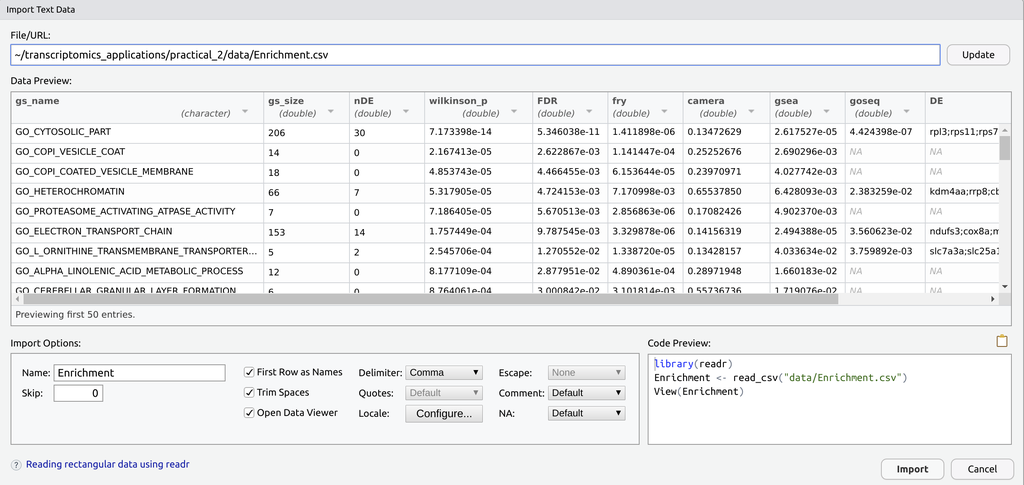

If the `Data Preview` part of the preview is blank, click the `Update` button and it will refresh. (This seems a bit glitchy sometimes.) **Don’t click `Import` just yet.**

Notice that in the main `Data Preview` section that R Studio has figured out:

1. We have comma-separated values. The suffix `.csv` is how it guessed this.
2. The first row contains column names
3. What type of values are in each column. You can see the data type in brackets underneath the column names.

An vitally important feature of the GUI is inthe bottom right, where we have bene given a preview of the **actual code that will be executed** to import that data into R.

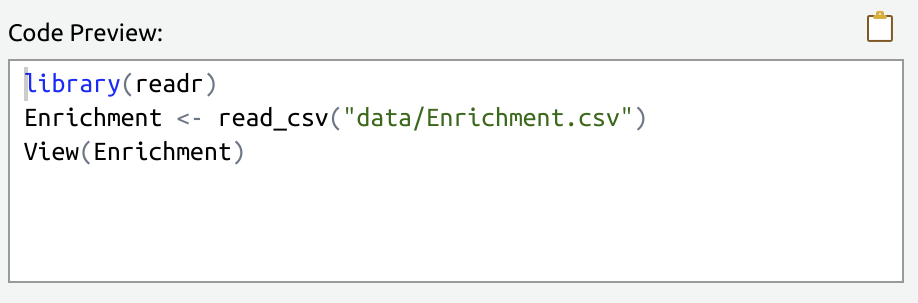

Here, there are three lines which we need to understand

1. `library(readr)`
2. `Enrichment <- read_csv("data/Enrichment.csv")`
3. `View(Enrichment)`

**Using your mouse, select and copy these three lines** then click the `Import` button and some crazy magic will happen. You’ll probably find yourself looking at an Excel-like preview, so before we move on, go to `DataImport.Rmd` and create a new chunk. Name the chunk `import` then paste these lines of code into the chunk.

Let’s see what we’ve actually done

### `library(readr)`

The first line is telling `R` to load the package `readr`. This package contains the function `read_csv()` which is what parses the plain-text file into the R Environment. We’ve already loaded this package in our first chunk as part of the `tidyverse`, so we can actually delete this line from our `import` chunk. (Please do so.)

### `Enrichment <- read_csv("data/Enrichment.csv")`

The second line is where the importing actually happens. Hopefully this looks like normal R code to you know, where we have an object name (`Enrichment`) followed by the assignment operator (`<-`). The data that we’re placing into this object is the output from the function `read_csv()`, and notice that here we have simply given the file path to this function, and it’s done the rest.

The GUI has automatically decided on the object name `Enrichment` as this was taken from the file name by dropping the `.csv` suffix.

### `View(Enrichment)`

The third line has opened up our Excel-like preview. For those who really like this format, this can provide a familiar way to inspect your data. However, for those who are R purists, this actually looks horrifying! Once you’ve had a quick browse, close the preview.

We’re also going to delete this third line from our `import` chunk. This preview is designed for interactive inspection of the data, and when we’re compiling our R Markdown document we can’t interact with the data like this.

An alternative way of viewing the data object is to simply enter the name of the object in the **Console**. Do this, and notice all of the information that has been presented to you here.

1. `# A tibble: 500 x 10`: This is a type of object known as a `tibble`, which is based on a `data.frame`, but wrapped in lovely wrapping paper so it looks nice. Notice that this output also tells us how many rows (500) and columns (10) that we have.
2. After that we have all of the column names, with the data type shown in grey underneath each column name.
3. Then we are shown a preview of the first 10 rows of data, followed by `# … with 490 more rows`. This is a great feature of tibbles, as a `data.frame` would dump all 500 rows onto the screen. Each column has also been truncated in the display so you get a peek at what every column looks like, without seeing all of the data. For this dataset, so of the columns are very, very wide so this also makes out lives easier.

These features are why many R users prefer this preview, as you can see all of that important summary information as well as having a sneak peak at the contents. Using the Excel-like `View()` command, in some people’s opinions, is actually **less** informative.

### Changing the Defaults

All of the settings for `read_csv()` were guessed by the R Studio GUI and for the most part, these will be correct. Can we change these using the GUI?

Re-open the GUI by clicking on the file, but once again don’t click `Import`.

1. Try changing the name to `enrichment` at the bottom left, then click anywhere else in the GUI. You’ll notice that the Code Preview has updated to reflect this.
2. Uncheck the `First Row as Names` check-box. **Clearly, this would be a bad idea for this dataset**. However, notice that the column names have now changed, the types of data in each column have changes, and the code has changed to include the argument `col_names = FALSE`. Re-check the check-box to make sure we don’t accidentally do anything silly.
3. Uncheck the `Open Data Viewer` check-box. **What changed?**
4. Change the `Delimiter:` drop-down menu to anything other than a comma. Although this would also be a bad idea for this dataset, notice that the code changes along with the preview. This may be useful if you have tab-separated data, or if you have any other delimiter.
5. Click the `Cancel` button to make sure we import anything silly into our R Environment.

In our last change above, the import function changed to `read_delim()` instead of `read_csv()`. `read_delim()` is actually the main function whilst `read_csv()` is actually a wrapper with all arguments preset to values that work for a `csv`. Additional functions like `read_tsv()` do the same thing for tab-separated files.

## Using Code to Import Data

Returning to our R Markdown. As you may have now figured out, we’ve kept the only line from our code that performs the actual data import.

```r
Enrichment <- read_csv("data/Enrichment.csv")
```

Have a look at your **Environment** Tab and you’ll see `Enrichment` sitting there. Now that we’ve saved our code for the import, click the broom symbol next to `Import Dataset` (). This will delete the object from your R Environment.

Now execute the chunk that has the import code, and it will reappear in your Environment. This is your first taste of *reproducible research*. We no longer have to click on everything, but can write the code to perform an operation.

After your `import` chunk, include the following lines.

> The object `Enrichment` was imported, which contained `` `r nrow(Enrichment)` `` gene sets.

Now compile your document and check the document we have generated. It’ll be pretty simple, but we’ve effectively automated data import, and printed a quick summary of some important information.

## What is in this object

In this object, we have 10 columns (*gs_name*, *gs_size*, *nDE*, *wilkinson_p*, *FDR*, *fry*, *camera*, *gsea*, *goseq* and *DE*), each of which contains different pieces of information.

1. `gs_name`: This is the name of the gene set that we have tested for being enriched in our results
2. `gs_size`: This is the number of genes in the complete gene set
3. `nDE`: This is the number of genes in the gene set that were formally considered as *differentially expressed* (DE) between the two genotypes
4. `wilkinson_p`: Is our p-value for enrichment after combining multiple tests
5. `FDR` is an adjusted p-value which tells us what proportion of our results are likely to be false if we choose the corresponding value from `wilkinson_p` as our threshold of significance
6. `fry, camera, gsea` and `goseq` are four different analyses we performed on our data. We then combined these p-values (using Wilkinson’s method) to obtain the value `wilkinson_p`. (For reference, `goseq` needs a list of formally declared DE genes, whilst the other analyses work on ranked lists.)
7. `DE` is the all of the gene names formally considered as DE that belong to each gene set

We’re now going to explore a whole series of functions in the package `dplyr` which we can use to extract key results from our enrichment analysis.